# Agricultural Commodity Price Prediction in India Using R

Name: Rohith Vannela | Roll No: 160124771061

26 October 2026

# 1 Introduction and Problem Statement

Agricultural commodity prices in India change over time because of supply and demand, seasons, weather and market conditions. These changes make it hard for farmers, traders and consumers to plan. This project studies historical market prices and builds time-series models to forecast future prices.

# 2 Objectives

1. Explore historical minimum, modal and maximum prices of a commodity.
2. Identify yearly trends and seasonal patterns.
3. Compare three forecasting models: Baseline, Moving Average and SARIMA.
4. Evaluate the models with MAE, RMSE and MAPE, and forecast one year ahead.

# 3 Dataset

- **Name:** Daily Commodity Prices India
- **Source:** Kaggle (originally from India’s AGMARKNET system)
- **URL:** https://www.kaggle.com/datasets/khandelwalmanas/daily-commodity-prices-india
- **Content:** daily wholesale market prices (Rs per quintal) by state, district, market, commodity and variety.
- **Used here:** yearly files for 2015 to 2025.

# 4 Data Preparation

Settings for the selected series are kept in one place. Change them to analyse another commodity.

```r
data_folder     <- "C:/v sem/IDS/csv"      # folder containing 2015.csv ... 2025.csv
rds_file        <- "monthly_data.rds"      # cached monthly data
selected_state     <- "Telangana"
selected_commodity <- "Brinjal"
selected_variety   <- "Brinjal"
prediction_year    <- 2026
```

Each yearly file is cleaned (invalid dates and non-positive prices removed) and daily prices are averaged to monthly values. The result is cached in an `.rds` file so the documentation knits quickly after the first run.

```r
if (file.exists(rds_file)) {
  monthly_data <- readRDS(rds_file)
} else {
  monthly_data <- bind_rows(lapply(2015:2025, function(yr) {
    read_csv(file.path(data_folder, paste0(yr, ".csv")),
             col_types = cols(.default = col_guess(),
                              Arrival_Date = col_character(),
                              Min_Price = col_double(),
                              Max_Price = col_double(),
                              Modal_Price = col_double()),
             show_col_types = FALSE) %>%
      mutate(Arrival_Date = as.Date(parse_date_time(Arrival_Date,
                                    orders = c("ymd", "dmy", "mdy"),
                                    quiet = TRUE))) %>%
      filter(!is.na(Arrival_Date), Min_Price > 0, Max_Price > 0,
             Modal_Price > 0) %>%
      mutate(State = trimws(State), Commodity = trimws(Commodity),
             Variety = trimws(Variety),
             Month = floor_date(Arrival_Date, "month")) %>%
      group_by(State, Commodity, Variety, Month) %>%
      summarise(Min_Price = mean(Min_Price), Max_Price = mean(Max_Price),
                Modal_Price = mean(Modal_Price), .groups = "drop")
  }))
  saveRDS(monthly_data, rds_file)
}

# Convert Rs per quintal to Rs per kg (1 quintal = 100 kg)
monthly_data <- monthly_data %>%
  select(State, Commodity, Variety, Month,
         Min_Price, Max_Price, Modal_Price) %>%
  mutate(Month = as.Date(Month),
         across(c(Min_Price, Max_Price, Modal_Price), ~ .x / 100))
```

A helper builds a continuous monthly series for one price column. Missing months are filled by linear interpolation.

```r
prepare_series <- function(data, price_column) {
  s <- data %>%
    group_by(Month) %>%
    summarise(Price = mean(.data[[price_column]], na.rm = TRUE),
              .groups = "drop") %>%
    filter(is.finite(Price), Price > 0) %>%
    arrange(Month) %>%
    complete(Month = seq(min(Month), max(Month), by = "month")) %>%
    arrange(Month)
  s$Price <- zoo::na.approx(s$Price, na.rm = FALSE)
  s$Price <- zoo::na.locf(s$Price, na.rm = FALSE)
  s$Price <- zoo::na.locf(s$Price, fromLast = TRUE, na.rm = FALSE)
  s
}

selected_data <- monthly_data %>%
  filter(State == selected_state, Commodity == selected_commodity,
         Variety == selected_variety)

stopifnot(nrow(selected_data) > 0)

eda <- prepare_series(selected_data, "Min_Price") %>% rename(Minimum = Price) %>%
  inner_join(prepare_series(selected_data, "Modal_Price") %>%
               rename(Modal = Price), by = "Month") %>%
  inner_join(prepare_series(selected_data, "Max_Price") %>%
               rename(Maximum = Price), by = "Month") %>%
  mutate(Year = year(Month), MonthLab = factor(month.abb[month(Month)],
                                               levels = month.abb))
```

The selected series is **Brinjal** (variety Brinjal) in **Telangana**, with **132 monthly observations** from Jan 2015 to Dec 2025.

# 5 Exploratory Analysis

## 5.1 Summary statistics (Rs per kg)

```r
f <- function(x) round(c(mean(x), median(x), sd(x), min(x), max(x),
                         sd(x) / mean(x) * 100), 2)
kable(data.frame(
  Statistic = c("Mean", "Median", "Std deviation", "Lowest", "Highest",
                "Variation (CV %)"),
  Minimum = f(eda$Minimum), Modal = f(eda$Modal), Maximum = f(eda$Maximum)))
```

| Statistic | Minimum | Modal | Maximum |
| --- | --- | --- | --- |
| Mean | 15.70 | 17.86 | 19.89 |
| Median | 15.81 | 17.95 | 19.23 |
| Std deviation | 8.10 | 8.01 | 8.18 |
| Lowest | 3.12 | 4.62 | 5.84 |
| Highest | 39.33 | 41.96 | 44.95 |
| Variation (CV %) | 51.57 | 44.83 | 41.12 |

# 6 Visualization

## 6.1 Heatmap of modal price by month and year

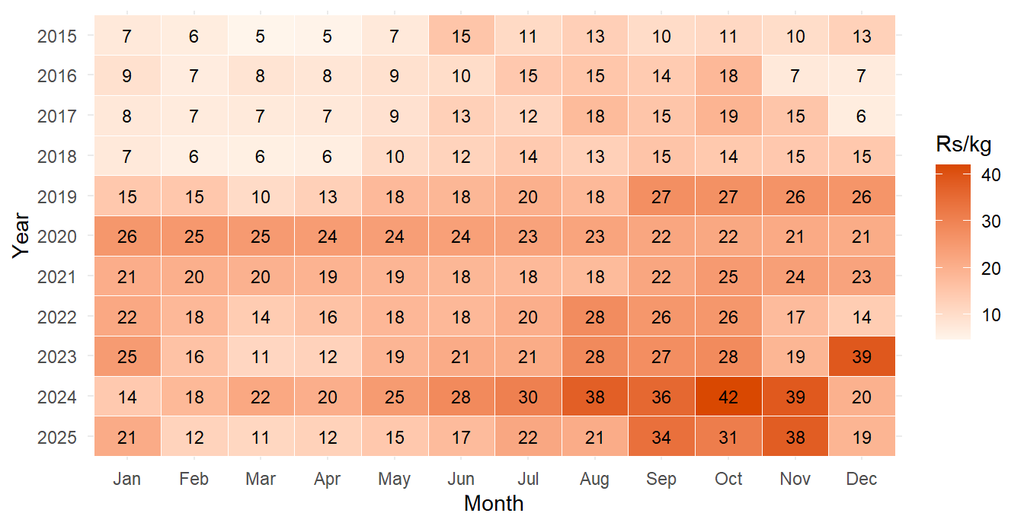

```r
ggplot(eda, aes(MonthLab, factor(Year), fill = Modal)) +
  geom_tile(colour = "white") +
  geom_text(aes(label = round(Modal, 0)), size = 3) +
  scale_fill_gradient(low = "#fff5eb", high = "#d94801") +
  scale_y_discrete(limits = rev) +
  labs(x = "Month", y = "Year", fill = "Rs/kg") +
  theme_minimal()
```

## 6.2 Average modal price per year

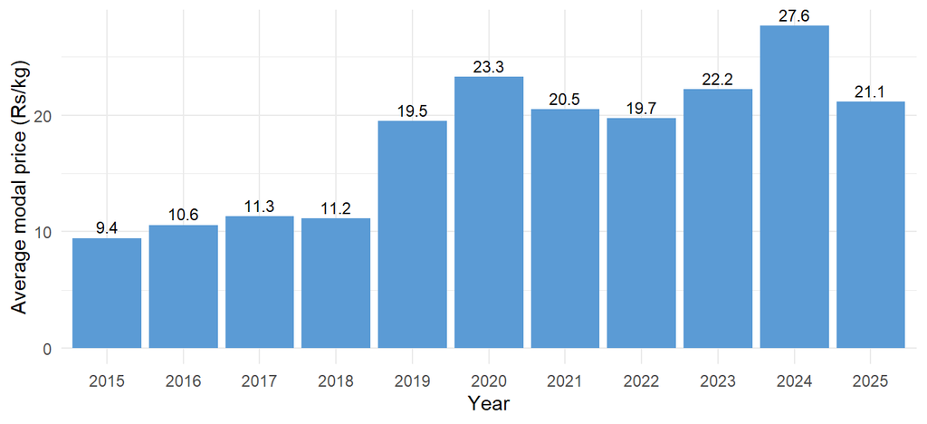

```r
eda %>% group_by(Year) %>% summarise(Average = mean(Modal), .groups = "drop") %>%
  ggplot(aes(factor(Year), Average)) +
  geom_col(fill = "#5b9bd5") +
  geom_text(aes(label = round(Average, 1)), vjust = -0.4, size = 3) +
  labs(x = "Year", y = "Average modal price (Rs/kg)") +
  theme_minimal()
```

On average, the modal price is highest in **Oct** (Rs 23.92/kg) and lowest in **Mar** (Rs 12.64/kg). The yearly average ranged from Rs 9.45/kg (2015) to Rs 27.65/kg (2024).

# 7 Prediction Models

Three models are compared. The last 12 months are held out as a test set; the models are trained on the earlier months.

- **Baseline:** every future month equals the last observed price.
- **Moving Average:** average of the last 3 months, rolled forward.
- **SARIMA:** seasonal ARIMA with a 12-month cycle, fitted on log prices with forced seasonal differencing (`auto.arima`, `D = 1`, `lambda = 0`).

The model with the lowest RMSE on the test set is refitted on all data to forecast the selected year.

```r
fit_sarima <- function(values, start_month) {
  s <- ts(values, start = c(year(start_month), month(start_month)),
          frequency = 12)
  fit <- tryCatch(auto.arima(s, seasonal = TRUE, D = 1, lambda = 0),
                  error = function(e) NULL)
  if (is.null(fit))
    fit <- tryCatch(auto.arima(s, seasonal = TRUE, lambda = 0),
                    error = function(e) NULL)
  fit
}

ma_forecast <- function(history, h, window = 3) {
  out <- numeric(h)
  for (i in seq_len(h)) {
    out[i] <- mean(tail(history, window))
    history <- c(history, out[i])
  }
  out
}

metric_row <- function(actual, predicted, model) {
  e  <- actual - predicted
  ok <- is.finite(predicted) & actual != 0
  data.frame(Model = model, MAE = mean(abs(e)), RMSE = sqrt(mean(e^2)),
             MAPE = if (any(ok)) mean(abs(e[ok] / actual[ok])) * 100 else NA)
}

forecast_series <- function(data, price_column, year_to_predict) {
  s      <- prepare_series(data, price_column)
  stopifnot(nrow(s) >= 36)
  values <- s$Price
  start  <- min(s$Month)
  last_m <- max(s$Month)
  horizon <- (year_to_predict - year(last_m)) * 12 + (12 - month(last_m))
  stopifnot(horizon >= 1)

  train <- head(values, length(values) - 12)
  test  <- tail(values, 12)

  base_t  <- rep(tail(train, 1), 12)
  ma_t    <- ma_forecast(train, 12)
  fit_t   <- fit_sarima(train, start)
  sarima_t <- if (is.null(fit_t)) rep(NA_real_, 12) else
    as.numeric(forecast(fit_t, h = 12)$mean)

  metrics <- bind_rows(metric_row(test, base_t, "Baseline"),
                       metric_row(test, ma_t, "Moving Average"),
                       metric_row(test, sarima_t, "SARIMA"))
  ok   <- metrics[is.finite(metrics$RMSE), ]
  best <- ok$Model[which.min(ok$RMSE)]

  pred <- switch(best,
    "Baseline"       = rep(tail(values, 1), horizon),
    "Moving Average" = ma_forecast(values, horizon),
    "SARIMA"         = as.numeric(forecast(fit_sarima(values, start),
                                           h = horizon)$mean))

  all_f <- data.frame(Month = seq(last_m %m+% months(1), by = "month",
                                  length.out = horizon),
                      Price = pmax(pred, 0.01))
  list(forecast = filter(all_f, year(Month) == year_to_predict),
       metrics = metrics, best = best,
       holdout = data.frame(Month = tail(s$Month, 12), Actual = test,
                            Baseline = base_t, `Moving Average` = ma_t,
                            SARIMA = sarima_t, check.names = FALSE))
}

targets <- c(Minimum = "Min_Price", Modal = "Modal_Price", Maximum = "Max_Price")
res <- lapply(targets, function(tg) forecast_series(selected_data, tg,
                                                    prediction_year))
```

# 8 Results

## 8.1 Model comparison on the 12-month test set (errors in Rs per kg)

```r
bind_rows(lapply(names(res), function(n)
  cbind(Price = n, res[[n]]$metrics))) %>%
  mutate(across(c(MAE, RMSE, MAPE), ~ round(.x, 2))) %>%
  kable()
```

| Price | Model | MAE | RMSE | MAPE |
| --- | --- | --- | --- | --- |
| Minimum | Baseline | 6.39 | 8.45 | 34.71 |
| Minimum | Moving Average | 10.89 | 11.86 | 78.78 |
| Minimum | SARIMA | 6.02 | 6.98 | 37.16 |
| Modal | Baseline | 6.66 | 8.59 | 32.93 |
| Modal | Moving Average | 11.23 | 12.36 | 71.17 |
| Modal | SARIMA | 7.59 | 8.46 | 42.31 |
| Maximum | Baseline | 7.02 | 8.84 | 31.99 |
| Maximum | Moving Average | 11.75 | 13.08 | 66.60 |
| Maximum | SARIMA | 7.74 | 8.71 | 38.89 |

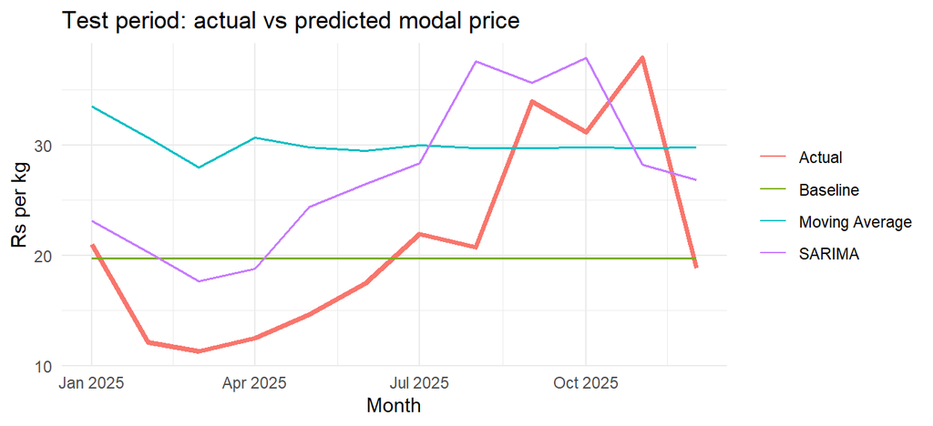

```r
res$Modal$holdout %>%
  pivot_longer(-Month, names_to = "Series", values_to = "Price") %>%
  ggplot(aes(Month, Price, colour = Series, linewidth = Series == "Actual")) +
  geom_line(na.rm = TRUE) +
  scale_linewidth_manual(values = c(`TRUE` = 1.4, `FALSE` = 0.7), guide = "none") +
  labs(title = "Test period: actual vs predicted modal price",
       x = "Month", y = "Rs per kg", colour = NULL) +
  theme_minimal()
```

For the modal price, the selected model is **SARIMA**. Its test RMSE is 8.46 Rs/kg, compared with 8.59 for the Baseline and 12.36 for the Moving Average.

## 8.2 Forecast for 2026 (Rs per kg)

```r
fc %>% mutate(Month = format(Month, "%b %Y"), across(-Month, ~ round(.x, 2))) %>%
  kable()
```

| Month | Minimum | Modal | Maximum |
| --- | --- | --- | --- |
| Jan 2026 | 20.71 | 24.14 | 25.87 |
| Feb 2026 | 14.91 | 16.50 | 18.99 |
| Mar 2026 | 13.34 | 15.26 | 17.51 |
| Apr 2026 | 13.89 | 16.04 | 18.15 |
| May 2026 | 17.10 | 21.39 | 24.14 |
| Jun 2026 | 19.47 | 24.70 | 27.54 |
| Jul 2026 | 20.52 | 27.43 | 29.94 |
| Aug 2026 | 22.09 | 32.06 | 35.23 |
| Sep 2026 | 23.36 | 37.50 | 39.93 |
| Oct 2026 | 23.86 | 38.22 | 41.04 |
| Nov 2026 | 19.70 | 34.23 | 36.57 |
| Dec 2026 | 17.63 | 30.58 | 33.41 |

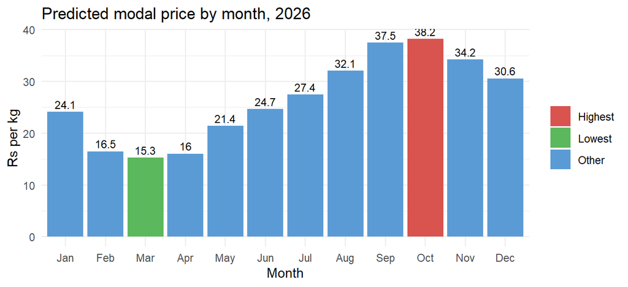

```r
fc$Label <- factor(format(fc$Month, "%b"), levels = format(fc$Month, "%b"))
fc$Status <- ifelse(fc$Modal == max(fc$Modal), "Highest",
                    ifelse(fc$Modal == min(fc$Modal), "Lowest", "Other"))
ggplot(fc, aes(Label, Modal, fill = Status)) +
  geom_col() +
  geom_text(aes(label = round(Modal, 1)), vjust = -0.4, size = 3) +
  scale_fill_manual(values = c(Highest = "#d9534f", Lowest = "#5cb85c",
                               Other = "#5b9bd5")) +
  labs(title = paste("Predicted modal price by month,", prediction_year),
       x = "Month", y = "Rs per kg", fill = NULL) +
  theme_minimal()
```

The highest predicted modal price is in **October 2026** (Rs 38.22/kg) and the lowest is in **March 2026** (Rs 15.26/kg).

# 9 Conclusion

- The 132-month history of Brinjal in Telangana shows a clear seasonal pattern, with the highest average prices in Oct and the lowest in Mar.
- On the 12-month test set, **SARIMA** had the lowest RMSE for the modal price (8.46 Rs/kg).
- The advantage of SARIMA over the Baseline can be small, so forecasts are estimates and not guarantees. Accuracy also falls for years further from the last observed data.
- Limitations: the test uses only 12 months, missing months are interpolated, and weather or policy effects are not modelled.
- Future work: add rainfall and arrival quantities, try other models, and evaluate with rolling-origin cross-validation.

# 10 Links

- **Dataset:** https://www.kaggle.com/datasets/khandelwalmanas/daily-commodity-prices-india

# 11 References

1. Kaggle. *Daily Commodity Prices India* (AGMARKNET data). https://www.kaggle.com/datasets/khandelwalmanas/daily-commodity-prices-india
2. Hyndman, R. J., & Athanasopoulos, G. *Forecasting: Principles and Practice* (3rd ed.). OTexts. https://otexts.com/fpp3/
3. Hyndman, R. J., & Khandakar, Y. (2008). Automatic time series forecasting: the forecast package for R. *Journal of Statistical Software*, 27(3).